# Introduction and Chp 2: Statistical Learning

# 1 Introduction

**Overview**

- Supervised: prediction/estimation of outputs based on inputs
- Unsupervised: inputs but no supervising outputs
- Regression: continuous/discrete data
- Classification: qualitative/categorical data
- Clustering: no output; principal components

**History**

- Method of Least Squares; Linear Regression: Legendre and Gauss
- Linear Discriminant Analysis: Fisher
- Logistic Regression: alternative to LDA
- Generalized Linear Models: Nelder and Wedderburn class of methods including linear and logistic
- Classification and Regression Trees: Breiman, Friedman, Olshen, and Stone (including cross-validation)
- Generalized Additive Models: Hastie and Tibshirani, class of non-linear extensions to GLM

**Matrix Notation**

- n is number of observations
- p is number of variables
- i is index of observations (i = 1, 2, …, n)
- j is index of variables (p = 1, 2, …, p)
- $\textbf{X}$ denotes $n \times p$ matrix whose $(i,j)$th element is $x_{i,j}$
- vector of length n = **a**
- vector of length of p or anything else = $x$
- scalar = $a $
- vector of length k = $a \in \mathbb{R}^k$
- $(\textbf{AB})_{ij} = \sum_{k=1}^d a_{ik}b_{kj}$

# 2 Statistical Learning

## 2.1 What is Statistical Learning

$Y = f(X) + \epsilon$

- $f$ is systematic information that X provides about Y
- $\epsilon$ is error term — independent of X and mean zero

### 2.1.1 Prediction vs Inference

- because error is zero on average, $\hat{Y} = \hat{f}(X)$
- will always be some error because true Y is also a function of $\epsilon$ which by definition cannot be predicted by X
  - $\epsilon$ may contain variables that are useful to predicting Y
  - $\epsilon$ is upper bound on accuracy

$$\begin{equation}
\begin{split}
E[(Y - \hat{Y})^2] &= E[(f(X) + \epsilon - \hat{f}(X))^2]\\
&= \underset{Reducible}{[f(X) - \hat{f}(X)]^2} + \underset{Irreducible}{Var(\epsilon)}
\end{split}
\end{equation}$$

- Prediction: X is easy to obtain by Y is not; use X to find Y
  - $\hat{f}$ is a black box; interested just in reducing the reducible error
- Understand how changes in X affect Y
  - $\hat{f}$ is no longer a black box; need to know the form

### 2.1.2 Parametric vs Non-Parametric

Want to find a function $\hat{f}$ such that $Y (X) $ for any observation (X,Y)

- Parametric models
  - 1. Make assumption about functional form
  - 2. Need procedure that uses data to fit/train model
  - called parametric b/c it reduces problem of estimating $f$ down to just estimating a set of parameters
  - often model chosen is not a perfect fit; but adding more parameters to smooth the fit will follow the errors and overfit
- Non-parametric
  - does not make explicit assumptions about the form of $f$
  - can accurately fit a wider range of possible shapes of $f$
  - however, need a large number of obs for accurate estimation

### 2.1.3 Accuracy vs Interpretability

- List descending Interpretability and Ascending Flexibility
  - Subset Selection Lasso
  - Least Squares
  - Generalized Additive Models/Trees
  - Bagging, Boosting
  - Support Vector Machines

### 2.1.4 Supervised vs Unsupervised Learning

Supervised: fit model that relates response to predictors for purposes of predictors or inference

Unsupervised: no associated y for vector of x * if there are p variables then there are $p(p-1)/2$ scatter plots possible

### 2.1.5 Regression vs Classification

Classification used more for qualitative variables

## 2.2 Assessing Model Accuracy

### 2.2.1 Measuring Quality of Fit

Need to quantify how close predicted value is to true response value; most common is mean squared error

$$MSE = \frac{1}{n} \sum_{i=1}^n (y_i - \hat{f}(x_i))^2$$

- squared diff between observed and predicted Y
- above equation is *training MSE* because it is from the training data; interested in MSE for unseen data; really interested in lowest *test MSE*
- **degrees of freedom** summarizes flexibility of a curve
- very low training MSE will often have high test MSE; can use cross-validation to help-control for this

### 2.2.2 Bias Variance Tradeoff

Differences between low training MSE and high test MSE is function of bias-variance tradeoff; can decompose MSE into:

$$E[y_0 - \hat{f}(x_0)]^2 = Var[\hat{f}(x_0)] + [Bias(\hat{f}(x_0))]^2 + Var(\epsilon)$$

- expected test MSE: $E[y_0 - \hat{f}(x_0)]^2$; is what we would obtain if repeatedly estimated $f$
- expected test MSE can never lie below $Var(\epsilon)$
- Variance: how much $\hat{f}$ would change if estimated using different data
  - overfitted model will change greatly if data is changed
- Bias: error from model selection; more flexible leads to less bias
- More flexible models: lower bias increased variance
- Good test set performance of statistical learning method requires low variance and low squared bias

### 2.2.3 Classification Setting

Measure accuracy of classification using *error rate*: proportion of mistakes made when applying $\hat{f}$ to training data; *training error*:

$$\frac{1}{n} \sum_{i=1}^n I(y_i \neq \hat{y}_i)$$

- $I$ is an indicator equal to 1 if they are not the same ($\neq$) and 0 otherwise
- corresponding *test error* is:
  $$Ave(I(y_0 \neq \hat{y}_0))$$
- a good classifier is one wher the test error is smallest

**Bayes Classifier**

On average minimum test error rate is given by classifier that assigns each obs to most likely class conditional on its predictor values — This is the Bayes Classifier

- simply assign a test observation with predictor vector $x_0$ to class $j$ for which $Pr(Y=j \vert X = x_0)$ is largest
- Example:
  - if two classes, Bayes classifier predicts class one if $Pr(Y = 1 | X = x_0) > 0.5$
  - where probabilit is equalt to 50% is Bayes Decision Boundary
- Bayes Error Rate: test error rate for classifiers
- Bayes classifier produces smallest possible test error rate
- Overall Bayes Error Rate is:
  $$1 - E[\max_{j} Pr(Y = j \vert X)]$$

**K-Nearest Neighbor**

Cannot compute Bayes Classifier for real data b/c we don’t know the conditional distribution of Y given X; can estimate $Y \vert x$ and then classify obs based on highest *estimated* probability; one example is KNN:

- With positive integer $K$ and test observation $x_0$, KNN identifies $K$ points in data closest to $x_0$; points represented by $N_0$
- Then estimate conditional probability for class $j$ as fraction of points in $N_0$ whose response values equal $j$:

$$Pr(Y = j \vert X = x_0) = \frac{1}{K} \sum_{i \in N_0} I(y_i = j)$$

- Then applies Bayes rule and classifies test obs

## 2.3 Lab: Introduction to R

```r
# Chapter 2 Lab: Introduction to R
# Load ISLR library for data
library(ISLR)
# Basic Commands
x <- c(1,3,2,5)
x
```

```
[1] 1 3 2 5
```

```r
x = c(1,6,2)
x
```

```
[1] 1 6 2
```

```r
y = c(1,4,3)
length(x)
```

```
[1] 3
```

```r
length(y)
```

```
[1] 3
```

```r
x+y
```

```
[1]  2 10  5
```

```r
ls()
```

```
[1] "A"         "Auto"      "cylinders" "f"         "fa"        "x"         "y"
```

```r
rm(x,y)
ls()
```

```
[1] "A"         "Auto"      "cylinders" "f"         "fa"
```

```r
rm(list=ls())
?matrix
x=matrix(data=c(1,2,3,4), nrow=2, ncol=2)
x
```

```
     [,1] [,2]
[1,]    1    3
[2,]    2    4
```

```r
x=matrix(c(1,2,3,4),2,2)
matrix(c(1,2,3,4),2,2,byrow=TRUE)
```

```
     [,1] [,2]
[1,]    1    2
[2,]    3    4
```

```r
sqrt(x)
```

```
         [,1]     [,2]
[1,] 1.000000 1.732051
[2,] 1.414214 2.000000
```

```r
x^2
```

```
     [,1] [,2]
[1,]    1    9
[2,]    4   16
```

```r
x=rnorm(50)
y=x+rnorm(50,mean=50,sd=.1)
cor(x,y)
```

```
[1] 0.995529
```

```r
set.seed(1303)
rnorm(50)
```

```
 [1] -1.1439763145  1.3421293656  2.1853904757  0.5363925179  0.0631929665  0.5022344825 -0.0004167247  0.5658198405
 [9] -0.5725226890 -1.1102250073 -0.0486871234 -0.6956562176  0.8289174803  0.2066528551 -0.2356745091 -0.5563104914
[17] -0.3647543571  0.8623550343 -0.6307715354  0.3136021252 -0.9314953177  0.8238676185  0.5233707021  0.7069214120
[25]  0.4202043256 -0.2690521547 -1.5103172999 -0.6902124766 -0.1434719524 -1.0135274099  1.5732737361  0.0127465055
[33]  0.8726470499  0.4220661905 -0.0188157917  2.6157489689 -0.6931401748 -0.2663217810 -0.7206364412  1.3677342065
[41]  0.2640073322  0.6321868074 -1.3306509858  0.0268888182  1.0406363208  1.3120237985 -0.0300020767 -0.2500257125
[49]  0.0234144857  1.6598706557
```

```r
set.seed(3)
y=rnorm(100)
mean(y)
```

```
[1] 0.01103557
```

```r
var(y)
```

```
[1] 0.7328675
```

```r
sqrt(var(y))
```

```
[1] 0.8560768
```

```r
sd(y)
```

```
[1] 0.8560768
```

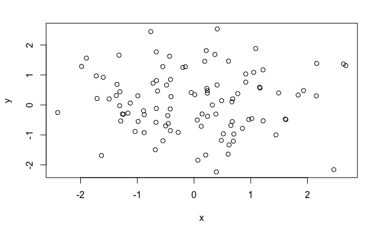

```r
# Graphics
x=rnorm(100)
y=rnorm(100)
plot(x,y)
```

```r
plot(x,y,xlab="this is the x-axis",ylab="this is the y-axis",main="Plot of X vs Y")
pdf("Figure.pdf")
```

[figure not shown]

```r
plot(x,y,col="green")
dev.off()
```

```r
x=seq(1,10)
x
```

```
 [1]  1  2  3  4  5  6  7  8  9 10
```

```r
x=1:10
x
```

```
 [1]  1  2  3  4  5  6  7  8  9 10
```

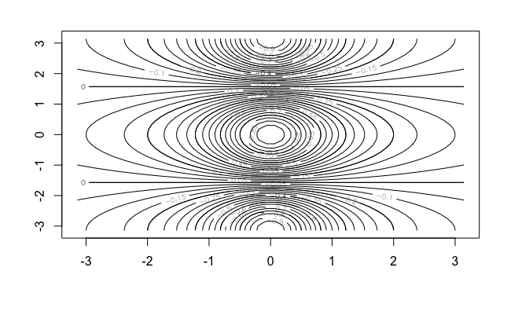

```r
x=seq(-pi,pi,length=50)
y=x
f=outer(x,y,function(x,y)cos(y)/(1+x^2))
contour(x,y,f)
contour(x,y,f,nlevels=45,add=T)
```

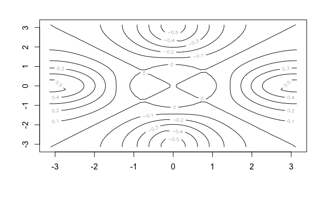

```r
fa=(f-t(f))/2
contour(x,y,fa,nlevels=15)
```

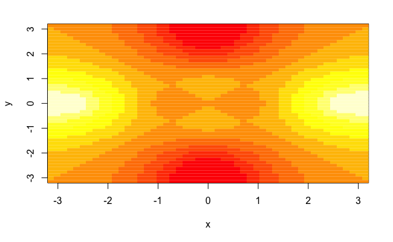

```r
image(x,y,fa)
```

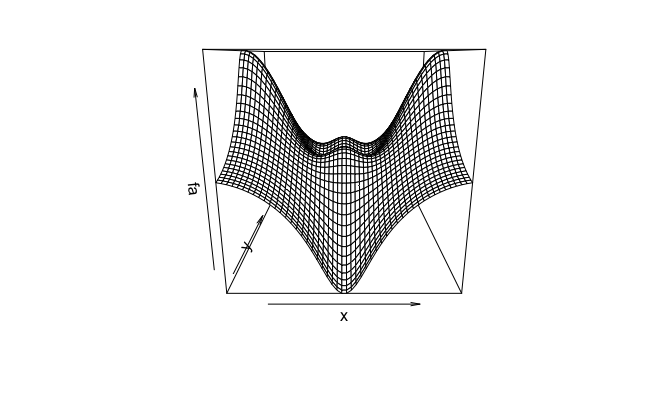

```r
persp(x,y,fa)
```

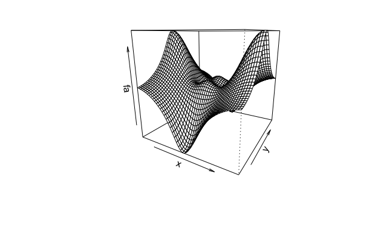

```r
persp(x,y,fa,theta=30)
```

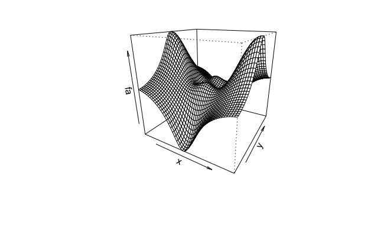

```r
persp(x,y,fa,theta=30,phi=20)
```

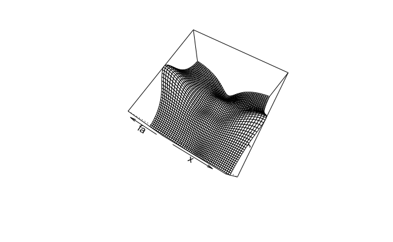

```r
persp(x,y,fa,theta=30,phi=70)
```

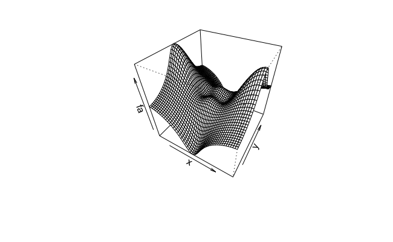

```r
persp(x,y,fa,theta=30,phi=40)
```

```r
# Indexing Data
A=matrix(1:16,4,4)
A
```

```
     [,1] [,2] [,3] [,4]
[1,]    1    5    9   13
[2,]    2    6   10   14
[3,]    3    7   11   15
[4,]    4    8   12   16
```

```r
A[2,3]
```

```
[1] 10
```

```r
A[c(1,3),c(2,4)]
```

```
     [,1] [,2]
[1,]    5   13
[2,]    7   15
```

```r
A[1:3,2:4]
```

```
     [,1] [,2] [,3]
[1,]    5    9   13
[2,]    6   10   14
[3,]    7   11   15
```

```r
A[1:2,]
```

```
     [,1] [,2] [,3] [,4]
[1,]    1    5    9   13
[2,]    2    6   10   14
```

```r
A[,1:2]
```

```
     [,1] [,2]
[1,]    1    5
[2,]    2    6
[3,]    3    7
[4,]    4    8
```

```r
A[1,]
```

```
[1]  1  5  9 13
```

```r
A[-c(1,3),]
```

```
     [,1] [,2] [,3] [,4]
[1,]    2    6   10   14
[2,]    4    8   12   16
```

```r
A[-c(1,3),-c(1,3,4)]
```

```
[1] 6 8
```

```r
dim(A)
```

```
[1] 4 4
```

```r
# Loading Data
Auto = Auto
dim(Auto)
```

```
[1] 392   9
```

```r
Auto[1:4,]
```

|  | mpg | cylinders | displacement | horsepower | weight | acceleration | year | origin | name |
| --- | --- | --- | --- | --- | --- | --- | --- | --- | --- |
| 1 | 18 | 8 | 307 | 130 | 3504 | 12.0 | 70 | 1 | chevrolet chevelle malibu |
| 2 | 15 | 8 | 350 | 165 | 3693 | 11.5 | 70 | 1 | buick skylark 320 |
| 3 | 18 | 8 | 318 | 150 | 3436 | 11.0 | 70 | 1 | plymouth satellite |
| 4 | 16 | 8 | 304 | 150 | 3433 | 12.0 | 70 | 1 | amc rebel sst |

```r
Auto=na.omit(Auto)
dim(Auto)
```

```
[1] 392   9
```

```r
names(Auto)
```

```
[1] "mpg"          "cylinders"    "displacement" "horsepower"   "weight"       "acceleration" "year"
[8] "origin"       "name"
```

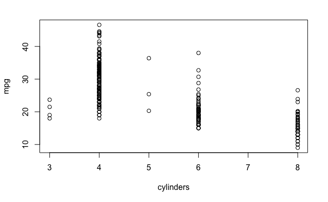

```r
# Additional Graphical and Numerical Summaries
attach(Auto)
plot(cylinders, mpg)
```

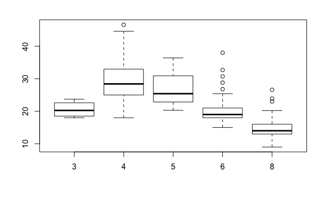

```r
cylinders=as.factor(cylinders)
plot(cylinders, mpg)
```

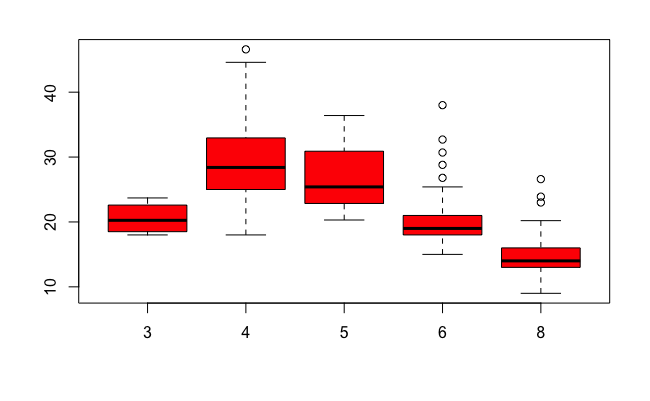

```r
plot(cylinders, mpg, col="red")
```

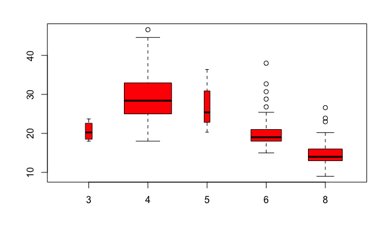

```r
plot(cylinders, mpg, col="red", varwidth=T)
```

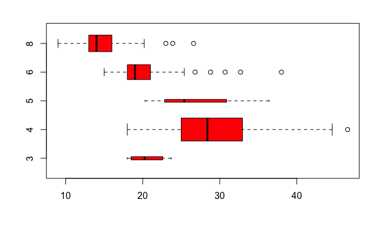

```r
plot(cylinders, mpg, col="red", varwidth=T,horizontal=T)
```

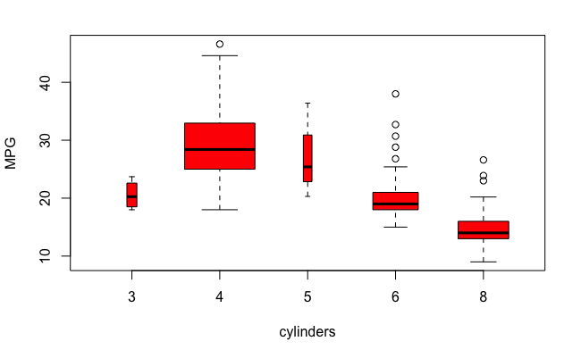

```r
plot(cylinders, mpg, col="red", varwidth=T, xlab="cylinders", ylab="MPG")
```

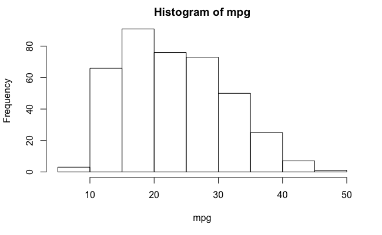

```r
hist(mpg)
```

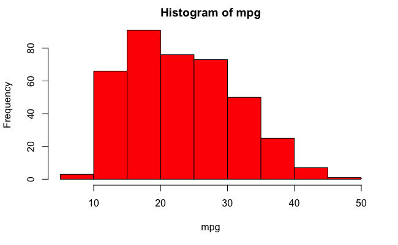

```r
hist(mpg,col=2)
```

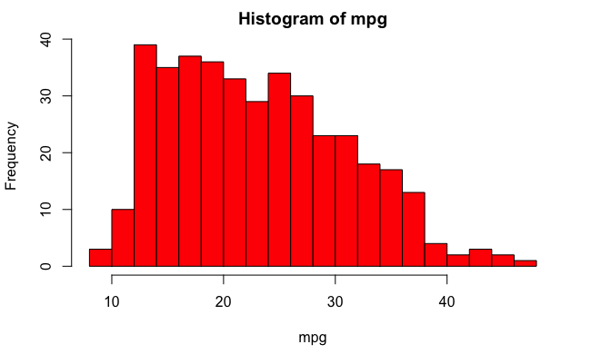

```r
hist(mpg,col=2,breaks=15)
```

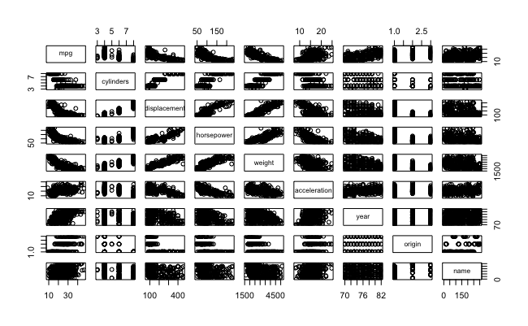

```r
pairs(Auto)
```

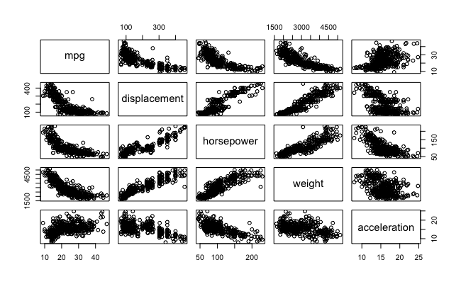

```r
pairs(~ mpg + displacement + horsepower + weight + acceleration, Auto)
```

```
integer(0)
```

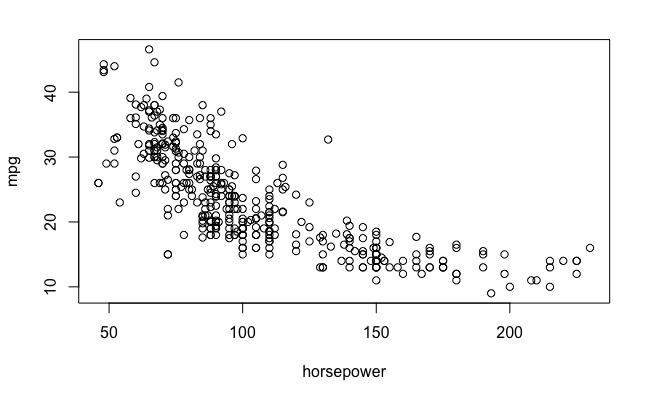

```r
plot(horsepower,mpg)
identify(horsepower,mpg,name)
```

```r
summary(Auto)
```

```
      mpg          cylinders      displacement     horsepower        weight      acceleration        year
 Min.   : 9.00   Min.   :3.000   Min.   : 68.0   Min.   : 46.0   Min.   :1613   Min.   : 8.00   Min.   :70.00
 1st Qu.:17.00   1st Qu.:4.000   1st Qu.:105.0   1st Qu.: 75.0   1st Qu.:2225   1st Qu.:13.78   1st Qu.:73.00
 Median :22.75   Median :4.000   Median :151.0   Median : 93.5   Median :2804   Median :15.50   Median :76.00
 Mean   :23.45   Mean   :5.472   Mean   :194.4   Mean   :104.5   Mean   :2978   Mean   :15.54   Mean   :75.98
 3rd Qu.:29.00   3rd Qu.:8.000   3rd Qu.:275.8   3rd Qu.:126.0   3rd Qu.:3615   3rd Qu.:17.02   3rd Qu.:79.00
 Max.   :46.60   Max.   :8.000   Max.   :455.0   Max.   :230.0   Max.   :5140   Max.   :24.80   Max.   :82.00

     origin                      name
 Min.   :1.000   amc matador       :  5
 1st Qu.:1.000   ford pinto        :  5
 Median :1.000   toyota corolla    :  5
 Mean   :1.577   amc gremlin       :  4
 3rd Qu.:2.000   amc hornet        :  4
 Max.   :3.000   chevrolet chevette:  4
                 (Other)           :365
```

```r
summary(mpg)
```

```
   Min. 1st Qu.  Median    Mean 3rd Qu.    Max.
   9.00   17.00   22.75   23.45   29.00   46.60
```